# KL Divergence

### Interpretation

Non-Zero Divergence: Both values are greater than 0. This immediately tells you that the two distributions (P for Control and Q for Treatment) are not identical. The new website design (Treatment group) did cause some shift in how users add items to their cart compared to the old design (Control group).

Magnitude of Divergence:

- The values (0.02823 and 0.02853) are relatively small. This indicates that while there is a difference, the overall shape or pattern of the distribution of "items added to cart" did not undergo a massive transformation.
- A KL divergence of 0 would mean the distributions are exactly the same. Values like 0.5, 1.0, or higher would indicate much more significant differences. In many practical scenarios, divergences below 0.1 are considered small.

Asymmetry:

- Notice that D_KL(P || Q) (0.02823) is slightly different from D_KL(Q || P) (0.02853). This confirms the asymmetrical nature of KL Divergence. The "information loss" is marginally different depending on which distribution you consider the reference. In this specific case, the difference between P || Q and Q || P is very small, which is expected for distributions that are already quite similar.

What the Divergence Implies about Behavior:

- To understand how the distributions differ, you'd look back at the actual probability values for each bin (e.g., "0 items," "1-2 items," etc.).
- Recall from our previous example, the Control group had a higher proportion of "0 items" and lower proportions in higher item categories compared to the Treatment group. The KL Divergence quantifies this collective shift.
- In practical terms: This small but non-zero divergence suggests that the new website design might have a subtle positive impact on user engagement related to adding items to the cart. While it's not a dramatic overhaul of behavior, it's a detectable shift.

What KL Divergence DOESN'T tell you (and why it's not a standalone A/B test metric):

- Statistical Significance: KL Divergence itself doesn't directly provide a p-value or confidence interval to tell you if this observed difference is statistically significant (i.e., unlikely to have occurred by chance). For that, you'd still rely on traditional statistical tests (e.g., a chi-squared test for comparing categorical distributions, or a t-test if you were focusing on the mean number of items).
- Direction of Change: While the number tells you how much they differ, you still need to look at the individual probability bins or a visualization (like the bar plot we generated) to understand in which direction the distribution shifted (e.g., more users adding 6+ items, fewer adding 0 items).

In conclusion:

A KL divergence of around 0.028 indicates that the new design (Treatment) did lead to a small, but discernible change in the overall pattern of how users add items to their cart compared to the old design (Control). This metric complements traditional A/B testing by giving you a single number to quantify the magnitude of this distributional shift.

### C. Visualization of the distribution

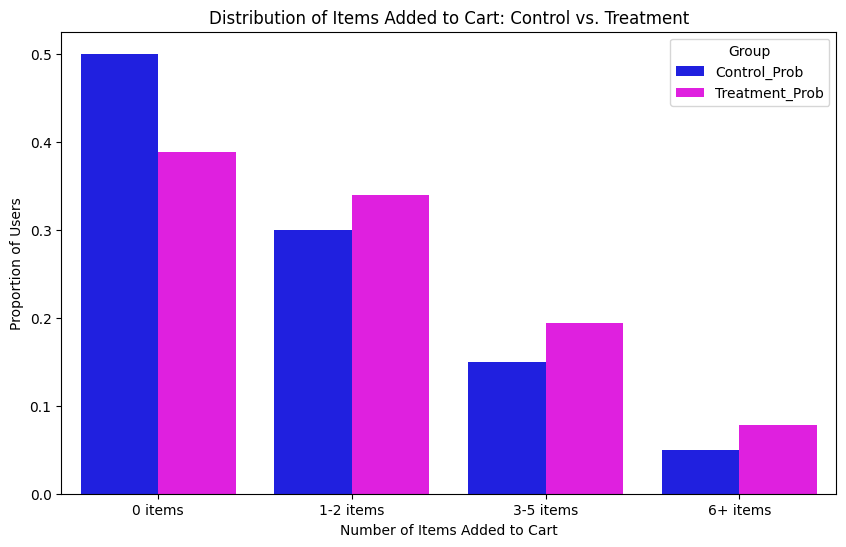

```
--- Visual Confirmation ---
The bar chart visually confirms the subtle shifts in probabilities between the Control and Treatment groups across the different item categories, which the KL Divergence quantifies.
```

```python
# --- Visualization of Distributions ---
df_dist = pd.DataFrame({
    'Category': item_bins,
    'Control_Prob': p_dist,
    'Treatment_Prob': q_dist
})

df_dist_melted = df_dist.melt(id_vars='Category', var_name='Group', value_name='Probability')

plt.figure(figsize=(10, 6))
sns.barplot(x='Category', y='Probability', hue='Group', data=df_dist_melted, palette={'Control_Prob': 'blue', 'Treatment_Prob': 'magenta'})
plt.title('Distribution of Items Added to Cart: Control vs. Treatment')
plt.xlabel('Number of Items Added to Cart')
plt.ylabel('Proportion of Users')
plt.show()

print("\n--- Visual Confirmation ---")
print("The bar chart visually confirms the subtle shifts in probabilities between the Control and Treatment groups across the different item categories, which the KL Divergence quantifies.")
```

Detailed interpretation:

Purpose of the Graph: The graph aims to show how a new feature or design (Treatment Group) impacts the distribution of items users add to their shopping carts compared to the existing design (Control Group). It's a key visual for an A/B test.

Overall Trend/Impact of Treatment:

- The graph clearly demonstrates a shift in the distribution of items added to the cart.
- The Treatment Group (new design) appears to be more effective at:
  - Reducing the proportion of users who add zero items.
  - Increasing the proportion of users who add multiple items (especially 3-5 and 6+ items).
- This suggests that the new feature/design might be encouraging users to engage more deeply with the product catalog and convert to larger carts.